# Project: Exploring Airbnb Market Trends

Aymen Nasri

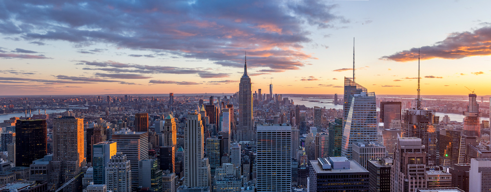

Welcome to New York City, one of the most-visited cities in the world. There are many Airbnb listings in New York City to meet the high demand for temporary lodging for travelers, which can be anywhere between a few nights to many months. In this project, you will take a closer look at the New York Airbnb market by combining data from multiple file types like .csv, .tsv, and .xlsx (Excel files).

Recall that CSV, TSV, and Excel files are three common formats for storing data. Three files containing data on 2019 Airbnb listings are available to you:

**data/airbnb_price.csv** This is a CSV file containing data on Airbnb listing prices and locations.

- listing_id: unique identifier of listing
- price: nightly listing price in USD
- nbhood_full: name of borough and neighborhood where listing is located

**data/airbnb_room_type.xlsx** This is an Excel file containing data on Airbnb listing descriptions and room types.

- listing_id: unique identifier of listing
- description: listing description
- room_type: Airbnb has three types of rooms: shared rooms, private rooms, and entire homes/apartments

**data/airbnb_last_review.tsv** This is a TSV file containing data on Airbnb host names and review dates.

- listing_id: unique identifier of listing
- host_name: name of listing host
- last_review: date when the listing was last reviewed

# Objectives :

- What are the dates of the earliest and most recent reviews? Store these values as two separate variables with your preferred names.
- How many of the listings are private rooms? Save this into any variable.
- What is the average listing price? Round to the nearest penny and save into a variable.
- Combine the new variables into one tibble called review_dates with four columns in the following order: first_reviewed, last_reviewed, nb_private_rooms, and avg_price. The tibble should only contain one row of values.

## Used libraries

```r
library(readr) # Used for reading csv and tsv files
library(readxl) # Used for reading excel files
library(stringr) # Used for string manipulation
library(dplyr) # Used for data manipulation
library(lubridate) # Used for dates manipulation
library(anytime) # Used for dates transformation
```

## Reading Data

```r
price_data <- read_csv("data/airbnb_price.csv")
rooms_data <- read_excel("data/airbnb_room_type.xlsx")
last_review_data <- read_tsv("data/airbnb_last_review.tsv")
```

## Data Wrangling/Cleaning :

#### Checking whether dates are written correctly and in same format or not

```r
head(last_review_data, n = 10)
```

| listing_id | host_name | last_review |
| --- | --- | --- |
| 2595 | Jennifer | May 21 2019 |
| 3831 | LisaRoxanne | July 05 2019 |
| 5099 | Chris | June 22 2019 |
| 5178 | Shunichi | June 24 2019 |
| 5238 | Ben | June 09 2019 |
| 5295 | Lena | June 22 2019 |
| 5441 | Kate | June 23 2019 |
| 5803 | Laurie | June 24 2019 |
| 6021 | Claudio | July 05 2019 |
| 6848 | Allen & Irina | June 29 2019 |

```r
is.Date(last_review_data$last_review)
```

```
## [1] FALSE
```

The observations are dates in the format %B %d %Y, we have to transform them to the %Y-%m-%d format using the anydate function from the library anytime.

```r
new_rev_data <- last_review_data %>%
  cbind(last_review_date = anydate(last_review_data$last_review)) %>%
  select(-last_review)
head(new_rev_data)
```

|  | listing_id | host_name | last_review_date |
| --- | --- | --- | --- |
| 1 | 2595 | Jennifer | 2019-05-21 |
| 2 | 3831 | LisaRoxanne | 2019-07-05 |
| 3 | 5099 | Chris | 2019-06-22 |
| 4 | 5178 | Shunichi | 2019-06-24 |
| 5 | 5238 | Ben | 2019-06-09 |
| 6 | 5295 | Lena | 2019-06-22 |

```r
is.Date(new_rev_data$last_review_date)
```

```
## [1] TRUE
```

#### Checking the rooms data and whether the room_type column is homogeneous or not

```r
head(rooms_data, n = 10)
```

| listing_id | description | room_type |
| --- | --- | --- |
| 2595 | Skylit Midtown Castle | Entire home/apt |
| 3831 | Cozy Entire Floor of Brownstone | Entire home/apt |
| 5099 | Large Cozy 1 BR Apartment In Midtown East | Entire home/apt |
| 5178 | Large Furnished Room Near B'way | private room |
| 5238 | Cute & Cozy Lower East Side 1 bdrm | Entire home/apt |
| 5295 | Beautiful 1br on Upper West Side | Entire home/apt |
| 5441 | Central Manhattan/near Broadway | Private room |
| 5803 | Lovely Room 1, Garden, Best Area, Legal rental | Private room |
| 6021 | Wonderful Guest Bedroom in Manhattan for SINGLES | Private room |
| 6848 | Only 2 stops to Manhattan studio | entire home/apt |

The private room value is written differently each time, we have to change all the observations to lower case using the str_to_lower function from the library stringr.

```r
new_room_data <- rooms_data %>%
  cbind(lower_room_type = str_to_lower(rooms_data$room_type)) %>%
  select(-room_type)
head(new_room_data, n = 10)
```

|  | listing_id | description | lower_room_type |
| --- | --- | --- | --- |
| 1 | 2595 | Skylit Midtown Castle | entire home/apt |
| 2 | 3831 | Cozy Entire Floor of Brownstone | entire home/apt |
| 3 | 5099 | Large Cozy 1 BR Apartment In Midtown East | entire home/apt |
| 4 | 5178 | Large Furnished Room Near B'way | private room |
| 5 | 5238 | Cute & Cozy Lower East Side 1 bdrm | entire home/apt |
| 6 | 5295 | Beautiful 1br on Upper West Side | entire home/apt |
| 7 | 5441 | Central Manhattan/near Broadway | private room |
| 8 | 5803 | Lovely Room 1, Garden, Best Area, Legal rental | private room |
| 9 | 6021 | Wonderful Guest Bedroom in Manhattan for SINGLES | private room |
| 10 | 6848 | Only 2 stops to Manhattan studio | entire home/apt |

#### Checking the prices data format

```r
head(price_data, n = 10)
```

| listing_id | price | nbhood_full |
| --- | --- | --- |
| 2595 | 225 dollars | Manhattan, Midtown |
| 3831 | 89 dollars | Brooklyn, Clinton Hill |
| 5099 | 200 dollars | Manhattan, Murray Hill |
| 5178 | 79 dollars | Manhattan, Hell's Kitchen |
| 5238 | 150 dollars | Manhattan, Chinatown |
| 5295 | 135 dollars | Manhattan, Upper West Side |
| 5441 | 85 dollars | Manhattan, Hell's Kitchen |
| 5803 | 89 dollars | Brooklyn, South Slope |
| 6021 | 85 dollars | Manhattan, Upper West Side |
| 6848 | 140 dollars | Brooklyn, Williamsburg |

```r
summary(is.na(price_data$price))
```

```
##    Mode   FALSE
## logical   25209
```

The prices are not numeric as they have the string “dollars” included, we’ll remove it using the str_remove function

```r
new_price_data <- price_data %>%
  cbind(price_usd = as.numeric(str_remove(price_data$price, "dollars"))) %>%
  select(-price)
summary(is.na(new_price_data$price_usd))
```

```
##    Mode   FALSE
## logical   25209
```

```r
is.numeric(new_price_data$price_usd)
```

```
## [1] TRUE
```

## Data Extraction :

#### Storing the earliest and the most recent reviews

```r
earliest_review <- min(new_rev_data$last_review_date)
most_recent_review <- max(new_rev_data$last_review_date)
earliest_review
```

```
## [1] "2019-01-01"
```

```r
most_recent_review
```

```
## [1] "2019-07-09"
```

#### Storing the number of private rooms listings

```r
priv_room_count <- as.numeric(new_room_data %>% filter(lower_room_type == "private room") %>%
  count())
priv_room_count
```

```
## [1] 11356
```

#### Storing the average listing price rounded to the nearest penny

```r
avg_price <- round(mean(new_price_data$price_usd), digits = 2)
avg_price
```

```
## [1] 141.78
```

## Storing the extracted data in a tibble and completing the last objective :

```r
review_dates <- tibble(earliest_review, most_recent_review,
                       priv_room_count, avg_price,
                       .name_repair = ~ c("first_reviewed", "last_reviewed",
                                          "nb_private_rooms", "avg_price"))
review_dates
```

| first_reviewed | last_reviewed | nb_private_rooms | avg_price |
| --- | --- | --- | --- |
| 2019-01-01 | 2019-07-09 | 11356 | 141.78 |